# Module 1 Project: Check Your Numbers

This is the output of one complete run of the project, with a fixed random seed. Use it to see whether your own results are in the right ballpark: the same order of magnitude, the same conclusions, the same first digit or two. It is not an answer key. There is no code and no explanation here, and the exam asks about *your* project, not this one.

What should match, and how closely:

- **Exact values** do not depend on random numbers and should match to every digit shown: $F(20)$ in A.1, the data fraction in A.4, the estimates in C.1 and C.2, and the observed $S^2$ in D.4.
- **Monte Carlo estimates** vary from run to run. Yours should be close, and where an exact value exists your confidence interval should contain it.
- **Choices are yours.** B.2 asks for two candidate envelopes, and this run picked one pair. Different candidates give different rows, and B.3 then starts from a different pilot variance. What should agree is the pattern.

# Part A: Monte Carlo integration

## A.1

The exact $F(20)$ from `pbeta`:

```
## [1] 0.289792
```

## A.2

The 95% confidence interval, then the estimate, from 10,000 $U(0, 20)$ draws. The interval should contain the A.1 value.

```
## [1] 0.2860319 0.2960499
## attr(,"conf.level")
## [1] 0.95
```

```
## [1] 0.2910409
```

## A.3

Numerical integration first. Then the Monte Carlo estimate of $\mathrm{E}(X)$ with its 95% interval, from 10,000 $U(0, 50)$ draws.

```
## 25 with absolute error < 2.8e-13
```

```
## estimate
## 25.20075 24.77805 25.62345
```

## A.4

The exact model probability beside the observed fraction of the 56 perch at or below 20 cm.

```
##     model      data
## 0.2897920 0.3392857
```

## A.5

$P(X_1 + X_2 > 70)$ from 100,000 uniform pairs: the estimate and its 95% interval.

```
##   estimate
## 0.04455501 0.04344487 0.04566515
```

# Part B: variance reduction

## B.1

```
##      anti     plain
## 0.2896803 0.2904301
```

```
## [1] 4.996446e-07
```

```
## [1] 6.519063e-06
```

```
## [1] 0.9233564
```

## B.2

One row per envelope, each with the estimate of $\mathrm{E}(X)$ and the estimated variance of the estimator from 10,000 draws. Your two candidates need not be these two; the uniform should be the worst row of your table.

```
##                  est          var
## uniform     24.98448 4.631474e-02
## candidate A 24.99322 7.027659e-03
## candidate B 25.00000 9.155236e-33
```

The `range()` of the 10,000 weighted values under the perfect envelope. Two copies of the same number:

```
## [1] 25 25
```

## B.3

The number of draws needed for a 95% interval of width at most 0.1 cm, using the pilot variance of the better non-perfect candidate above. Then the realized interval and its width from a run of that size.

```
## [1] 105572
```

```
##         lo         hi      width
## 24.9595801 25.0603833  0.1008032
```

# Part C: Monte Carlo for estimation

## C.1

The sample variance of the 56 perch lengths, then the method-of-moments estimate $\tilde a$.

```
## [1] 73.30052
```

```
## [1] 3.763271
```

## C.2

The statistic $T$, then the maximum-likelihood estimate $\hat a$.

```
## [1] -85.14177
```

```
## [1] 3.962164
```

## C.3

Bias and MSE of the two estimators of $F(20)$ at $n = 56$ from 1,000 replications, each with its 99% interval, and the boxplot. The dashed line is the exact $F(20)$.

```
##            bias  bias.lo  bias.hi     mse  mse.lo  mse.hi
## ecdf    0.00092 -0.00403  0.00587 0.00367 0.00327 0.00407
## plugin -0.00156 -0.00310 -0.00002 0.00036 0.00031 0.00040
```

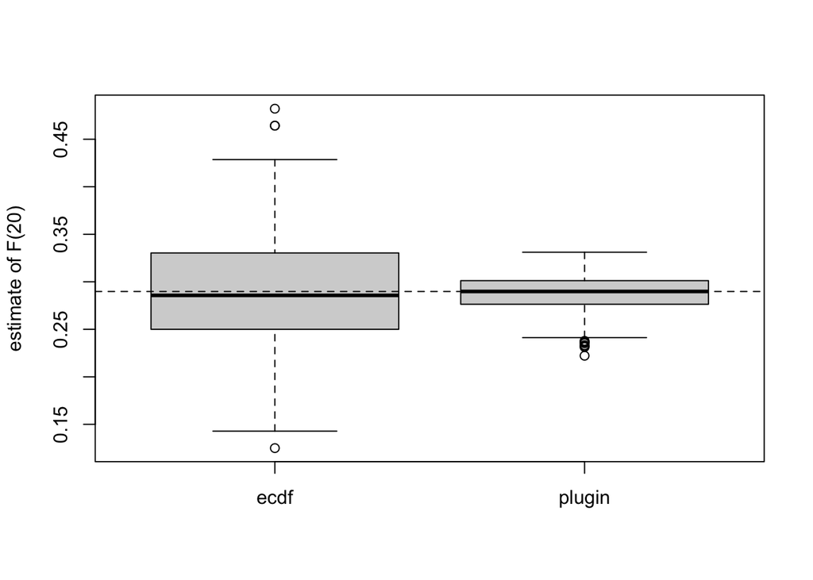

## C.4

Bias, variance and MSE of both estimators at all three sample sizes.

| n | estimator | bias | variance | mse |
| --- | --- | --- | --- | --- |
| 14 | ecdf | 0.00092 | 0.01525 | 0.01523 |
| 14 | plugin | -0.00816 | 0.00174 | 0.00181 |
| 56 | ecdf | 0.00014 | 0.00395 | 0.00395 |
| 56 | plugin | -0.00201 | 0.00034 | 0.00034 |
| 224 | ecdf | 0.00004 | 0.00095 | 0.00095 |
| 224 | plugin | -0.00042 | 0.00008 | 0.00008 |

## C.5

Two `binom.test` printouts. First the coverage of the nominal 95% $t$ interval over 10,000 samples of size 56. Second the direct-sampling check of A.5 over 100,000 pairs. In each, compare the estimated proportion and its 99% interval.

```
##
##  Exact binomial test
##
## data:  sum(cover) and 10000
## number of successes = 9495, number of trials = 10000, p-value < 2.2e-16
## alternative hypothesis: true probability of success is not equal to 0.5
## 99 percent confidence interval:
##  0.9435920 0.9549752
## sample estimates:
## probability of success
##                 0.9495
```

```
##
##  Exact binomial test
##
## data:  sum(pair) and 1e+05
## number of successes = 4515, number of trials = 1e+05, p-value < 2.2e-16
## alternative hypothesis: true probability of success is not equal to 0.5
## 99 percent confidence interval:
##  0.04347541 0.04686804
## sample estimates:
## probability of success
##                0.04515
```

# Part D: Monte Carlo for testing

## D.1

The two-sided cutoffs for $T_S$, then the one-sided cutoff for $T_K$, from 10,000 null samples.

```
##     2.5%    97.5%
## 48.54061 92.99846
```

```
##       95%
## 0.1769715
```

## D.2

The empirical Type I error rate of each region from 10,000 fresh null samples, as a 95% `binom.test` interval: $T_S$ first, then $T_K$.

```
## [1] 0.04188120 0.05018585
## attr(,"conf.level")
## [1] 0.95
```

```
## [1] 0.04676942 0.05549443
## attr(,"conf.level")
## [1] 0.95
```

## D.3

Power curves for both tests over $a \in \{2, 2.5, \ldots, 8\}$, 1,500 samples of size 56 at each value.

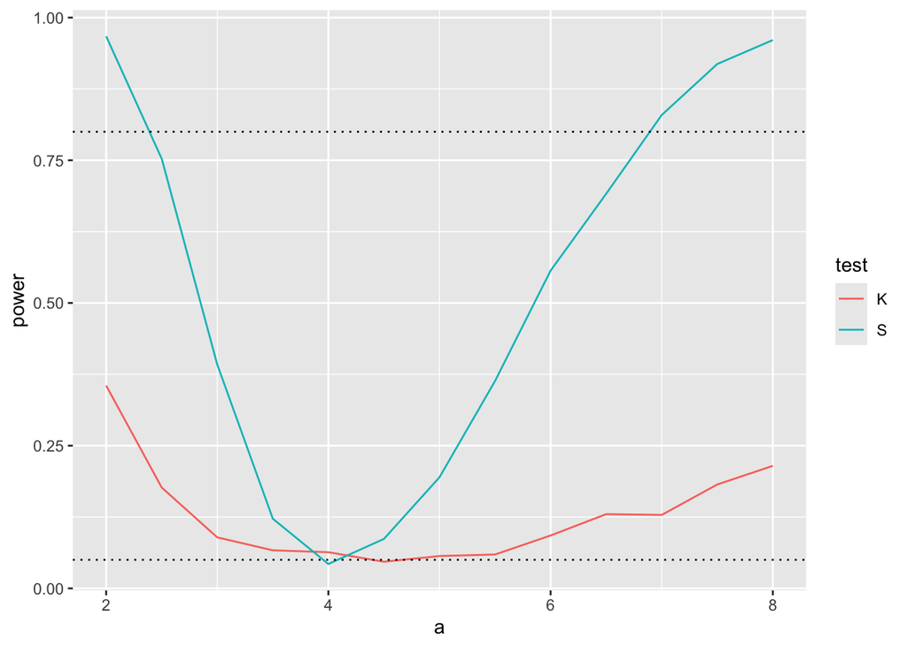

## D.4

**(a)** The observed $S^2$ for the 56 perch and its two-sided $p$-value.

```
##         S2          p
## 73.3005195  0.7163284
```

**(b)** The endpoints of the 95% confidence interval for $a$, whether the kept grid values form one unbroken run, and the plot of which grid values were kept. The dashed line is $\tilde a$ from C.1; the dotted line is the working value $a = 4$.

```
## [1] 2.6 5.3
```

```
## [1] TRUE
```

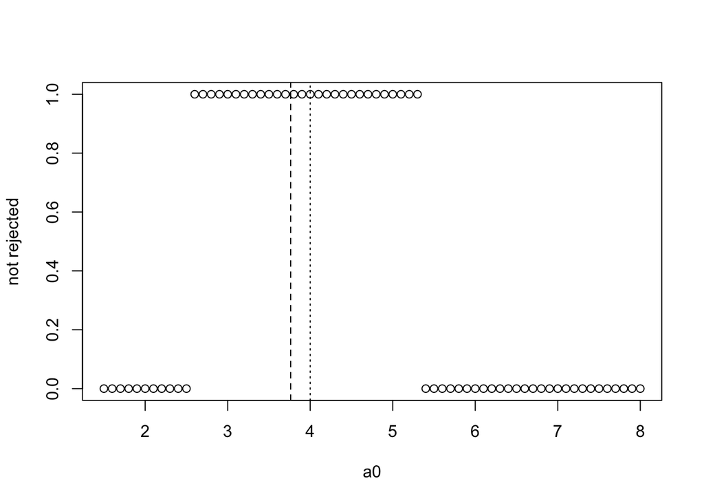